# Using the MBAOD package

Andrew C. Hooker

2014-11-05

# 1 Introduction

The MBAOD (Model Based Adaptive Optimal Design) package can be used to simulate clinical trials using predefined adaptive and optimization rules. In addition the package can be used to optimize any specific cohort of an actual study using MBAOD.

Adaptive designs (AD), in general, are a way to adapt experiments as your understanding of the system you are studying improves through intermediate analyses of the experimental data. Adaptive **optimal** design (AOD) uses optimal design theory as a way to design the next stage of your study. In this package we are assuming the use of **population** models for both the estimation of parameters (analysis of data) as well as for the optimization of the various cohorts of our experiment (see figure ).

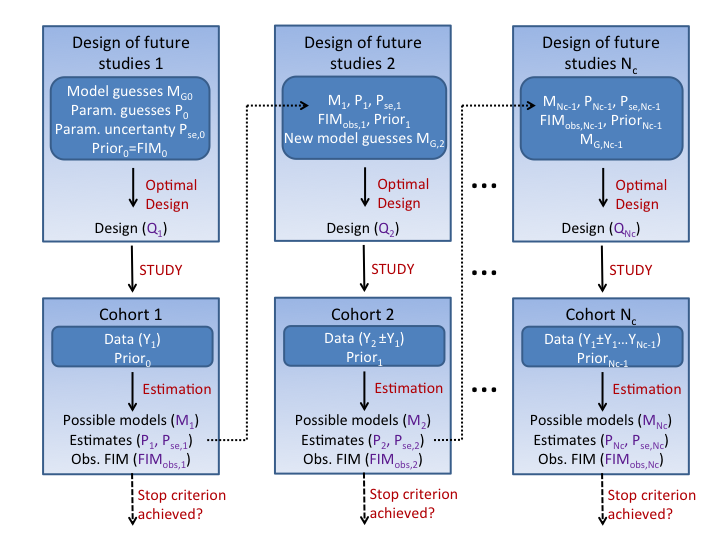

General schematic of a model based adative optimal design.

This package currently uses PopED, NONMEM, PsN and R to handle the various tasks inherent to simulating and evaluating an MBAOD experiment (see figure ). The code has been written to be (hopefully) quite modular, so that other tools can easily be switched in place of the current tool set (e.g. PFIM instead of PopED).

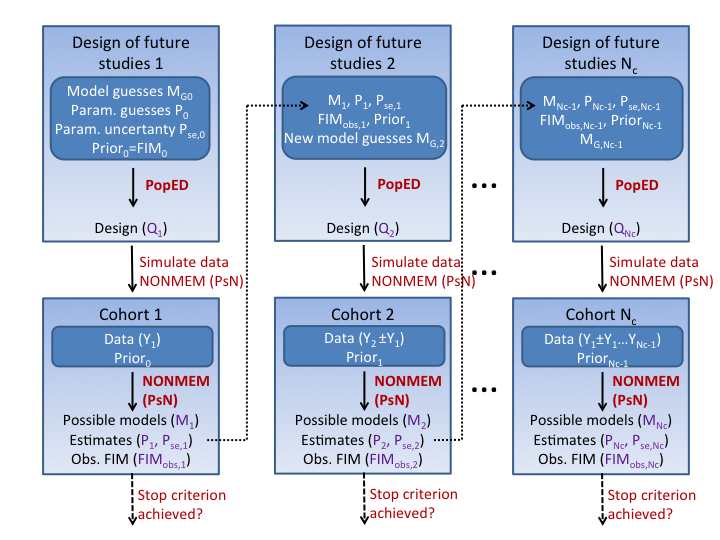

Specific schematic of MBAOD implemented in the MBAOD package. The entire process can be repeated multiple times and then the results of those repeated simulations can be summarized using R.

This document describes how to install and use the MBAOD (Model Based Adaptive Optimal Design) package.

# 2 Installation

1. You need to have R installed. Download the latest version of R from http://www.r-project.org.
2. Install PopED for R (https://github.com/andrewhooker/PopED). To install the latest stable release from CRAN, write at the R command line:

```r
    install.packages("PopED")
```

3. NONMEM and PsN (http://psn.sf.net) should be installed.
4. Download the MBAOD package from https://github.com/andrewhooker/MBAOD. On the right hand side of the page there are links to “Clone in Desktop” and “Download ZIP”. Alternatively, if you want to use the latest version of MBAOD but aren’t interested in developing the code, you can use the `devtools::install_github()` from the R command line. The `install_github()` approach requires that you build a package from source, i.e. `make` and compilers must be installed on your system – see the R FAQ for your operating system ; you may also need to install dependencies manually:

```r
    devtools::install_github("MBAOD",username="andrewhooker")
```

# 3 Overview of the MBAOD package

The MBAOD package’s main tool is the `mbaod_simulate()` function, which simulates model based adaptive design scenarios. The function’s main argument `cohorts` accepts a list of cohorts to run. Each cohort, in turn, is a list of, potentially, 4 named lists: “design”, “optimize”, “simulate” and “estimate”. Each list can be `NULL` or a list of elements:

- “design” is a list that defines the (initial) design for that cohort.
- “optimize” is a list that defines what to do for the optimization segment for that cohort.
- “simulate” is a list that defines what to do for the simulation segment for that cohort.
- “estimate” is a list that defines what to do for the estimation segment for that cohort.

There are a number of optional arguments (see `args(mbaod_simulate)`) including:

- `ncohorts` specifies the number of cohorts in the adaptive design procedure. If larger than the length of `cohorts` then the cohort information is inhereted from the last cohort in the list.
- `rep` specifies the number of times the adaptive design procedure should be repeated.

The MBAOD package also has a few plotting functions to visualize the output from `mbaod_simulate()`, including `mbaod_vpc()` and `plot_parameter_estimates()`.

In order to show how the MBAOD package works we present below some working examples.

# 4 An example: Adaptive design of a PK bridging study from adults to children

In this example we will simulate multiple realizations of a hypothetical clinical trial to bridge the pharmacokinetics (PK) of an adult population into a children.

## 4.1 The Model

### 4.1.1 The adult model

We assume that the drug PK in adults can be described by a one-compartment model additive and proportional residual error. For each individual $i$ we have:

$\begin{aligned} y_i=\frac{DOSE_i}{V_i} \cdot e^{-({CL}_i/V_i) \cdot t_i} \cdot (1+\varepsilon_{prop,i}) + \varepsilon_{add,i} \end{aligned}$

We assume a log-normal distribution of parameter values within individuals of the study population, thus, for $P \in (C{L},V)$ we have:

$P_i = P_{pop} \cdot e^{\eta_{P,i}}, \; \; \eta_{P,i} \in N(0,\omega^2_{P})$

We also assume that the residual error terms come from normal distributions:

$\varepsilon_j \in N(0,\sigma^2_{j})$

### 4.1.2 The maturation model

There are several methods that can be used to describe the link between PK in adults and children. For this example we use a relatively simplistic approach assuming an emax maturation function for CL dependent on weight (WT) as well as a weight adjusted volume parameter:

$\begin{aligned} {CL}_i & = {CL}_{BASE,i} + \frac{{CL}_{MAX} \cdot {WT}_i^\gamma }{{WT50}^\gamma + {WT}_i^\gamma } \\ V_i & = V_{STD,i} \cdot \frac{{WT}_i}{70} \end{aligned}$

Where $V_{STD,i}$ and ${CL}_{BASE,i}$ are assumed log-normally distributed as above.

### 4.1.3 Parameter values

We assume that the underlying true model of the system is the “Adult model” with $CL_i$ and $V_i$ defined by the “Maturation model”. Parameters for all simulations are (the “true” parameter values):

The true parameter values

| $CL_{BASE, pop}$ | $V_{STD, pop}$ | $CL_{MAX}$ | $WT50$ | $\gamma$ | $\omega_{CL_{BASE}}$ | $\omega_{V_{STD}}$ | $\sigma_{prop}$ | $\sigma_{add}$ |
| --- | --- | --- | --- | --- | --- | --- | --- | --- |
| 1 | 20 | 2 | 25 | 5 | 0.224 | 0.224 | 0.122 | 0.0387 |

## 4.2 Design 1: One weight group per cohort

In this design, we begin by simulating an initial cohort of adult patients using a fixed design. Parameter estimates from that initial cohort are then used to optimize the next cohort containing children. Optimization wiLL be on the weights as well as the sample times of the future cohorts. In this design we assume that each new cohort will contain groups of individuals with only one value of weight. An obvious simplification, but a starting point none-the-less.

The R commands found below are also available as an R script in the code repository in the directory “/inst/examples/Ex_1_bridging/poped_r/Example_1.R”. We begin our example by setting the path to this directory

```r
setwd("~/Documents/_PROJECTS/AOD/repos/MBAOD/inst/examples/Ex_1_bridging/poped_r")
```

Next we load the MBAOD package. Change the path in the code below to where you have the code on your computer. If you used the `install_github()` method to install MBAOD then a simple `library(MBAOD)` will work instead.

```r
devtools::load_all("~/Documents/_PROJECTS/AOD/repos/MBAOD")
```

### 4.2.1 Defining the first cohort

Now we can define the first cohort in the model based adaptive optimal design.

```r
cohort_1=list(
  design = list(
    groupsize = 50,
    a = c(WT=70),
    xt = c(0.1,1,2,4,6,8,24)),
  optimize=NULL,
  simulate=list(target="NONMEM",
                model="./NONMEM_files/sim.mod",
                data=list(dosing = list(list(AMT=1000,Time=0)),
                          manipulation = list(expression(AMT <- AMT*WT/70)))
                ),
  estimate=list(target="NONMEM",
                model="./NONMEM_files/est_red.mod"))
```

#### 4.2.1.1 The `design` argument

The elements of the `design` list are passed as arguments to the function `create_design()` to create a design object. The code above creates a design with one group of 50 individuals, all of whom weigh 70 kg and have 7 identical sample times. The allowed arguments to can be seen with `args(create_design())` and are described  
in the documentation for `?PopED::create.poped.database` (look in the “Arguments” section, under “START OF INITIAL DESIGN OPTIONS”).

#### 4.2.1.2 The `optimize` argument

The `optimize=NULL` argument indicates that we do not optimize this cohort’s design in any way.

#### 4.2.1.3 The `simulate` argument

The `target` argument determines which tool is used to simulate data. Currently `"NONMEM"` and `"poped_R"` are allowed options.

The `data` argument contains a list information about adding and manipulating columns in the simulation dataset. The `dosing` argument in this list is a list of lists that adds dosing records to the simulation dataset (Each inner list corresponding to a group in the cohort design). The `manipulation` agument is used to transform the resulting columns of the dataset (or create new columns), and is a list of one or more `expression()` arguments. For example the above code adds dosing records `AMT=1000` at `Time=0` and trandforms the `AMT` column of the dataset to be dependent on `WT` (we know `WT` to be 70 in this first cohort but this will be optimized, and therefore unknown before the experiment, in future cohorts).

The `model` argument is the model that should be used for the simulation. If your target is NONMEM then there are a number of rules for creating the simulation model file. First, by default the name of the simulation data file created by the MBAOD package is called “sim_data.csv” (see argument `sim_data_input_fn` in `mbaod_simulate()`). One should use this name in the `$DATA` section of the model file. Additionally the `$INPUT` section of the model file should expect the structure of the simulation input data file `sim_data_input_fn`. Currently the code use the create this dataset is:

```r
sim_data <- model_prediction(DV=T,
                             design=cohort_1$design,
                             dosing=cohort_1$simulate$data$dosing,
                             manipulation=cohort_1$simulate$data$manipulation)
head(sim_data)
```

```
## Source: local data frame [6 x 9]
##
##   ID Time DV IPRED PRED  AMT Group Model WT
## 1  1  0.0 NA    NA   NA 1000     1     1 70
## 2  1  0.1 NA    NA   NA   NA     1     1 70
## 3  1  1.0 NA    NA   NA   NA     1     1 70
## 4  1  2.0 NA    NA   NA   NA     1     1 70
## 5  1  4.0 NA    NA   NA   NA     1     1 70
## 6  1  6.0 NA    NA   NA   NA     1     1 70
```

Additionally, the NONMEM simulation model must have parameter estimates that are the “true” parameters for your system. Finally, the NONMEM simulation model must produce a table file that can be used for estimation, and the name of that table file must be “mc_sim_1.tab” (i.e. the name defined in `sim_data_output_fn` from `mbaod_simulate()`).

If you were to use PopED in R for simulation instead of NONMEM then your simulation argument would look something like:

```r
source("./PopED_files/poped.mod.PK.1.comp.maturation.R") # load the PopED model file

cohort_1_poped_sim  <- cohort_1
cohort_1_poped_sim$simulate <-
  list(target="poped_R",
       model = list(ff_file="PK.1.comp.maturation.ff",
                    fError_file="feps.add.prop",
                    fg_file="PK.1.comp.maturation.fg"),
       parameters = list(
         bpop=c(CL=1,V=20,EMAX=2,EC50=25,HILL=5),
         d=c(CL=0.05,V=0.05),
         sigma=c(PROP=0.015,ADD=0.0015)),
       data=list(dosing = list(list(AMT=1000,Time=0)),
                 manipulation = list(expression(AMT <- AMT*WT/70),
                                     expression(IPRED <- NULL),
                                     expression(PRED <- NULL),
                                     expression(Group <- NULL),
                                     expression(Model <- NULL))))
```

Here we define the `model` as a PopED model with `parameters` as the “true” model parameters. The allowed structure of the models and parameters section of this code is described in `?PopED::create.poped.database` (look in the “Arguments” section, under “START OF MODEL DEFINITION OPTIONS” and “START OF Model parameters SPECIFICATION OPTIONS”). Additionally we remove unneeded columns in the dataset directly with the `manipulation` argument, instead of doing this in the NONMEM code. Currently the code used to create the simulation dataset using PopED in R is (directly creating `sim_data_output_fn`):

```r
cohort <- cohort_1_poped_sim
poped.db <- do.call(create.poped.database,
                              c(do.call(create_design,cohort$design),
                                cohort$simulate$model,
                                cohort$simulate$parameters))

sim_data <- model_prediction(poped.db=poped.db,
                             DV=T,
                             dosing=cohort$simulate$data$dosing,
                             manipulation=cohort$simulate$data$manipulation)

head(sim_data)
```

```
## Source: local data frame [6 x 5]
##
##   ID Time       DV  AMT WT
## 1  1  0.0       NA 1000 70
## 2  1  0.1 39.06067   NA 70
## 3  1  1.0 47.31351   NA 70
## 4  1  2.0 34.03859   NA 70
## 5  1  4.0 29.05528   NA 70
## 6  1  6.0 16.87636   NA 70
```

#### 4.2.1.4 The `estimate` argument

In this first cohort we estimate on a reduced model without any maturation components as the data is not rich enough to estimate all parameters of the full model.

The `target` argument determines which tool is used to estimate data. Currently `"NONMEM"` is the allowed option. The `model` argument is the model that should be used for the estimation. There are a number of rules for creating the estimation model file. The estimation file name to use in the `$DATA` section is called “est.dat”. The `$INPUT` section should match the structure seen in the  
the `sim_data_output_fn`.

### 4.2.2 Defining the second cohort

The second cohort of patients is the first group of chldren. We assume in this example that each cohort contains a homogenous group, all with the same (optimized) weight. Our initial design is a weight half-way between 0 and 70 kg.

```r
cohort_2 <- cohort_1
cohort_2$design <- list(
  groupsize = 20,
  a   = c(WT=35),
  xt = c(0.5,1,2,3,6,12,24)
  )
```

Next we define the how we would like to optimize this design. In this case with PopED in R using the true model, a design space for the covariate (a) and the sample times (xt). Defining the `model` and `design_space` are as in `?PopED::create.poped.database` (look in the “Arguments” section, under “START OF MODEL DEFINITION OPTIONS” and “START OF DESIGN SPACE OPTIONS”).

The parameters for optimization are defined from the estimation in the previous step. However, since only a reduced model was used for that estimation, additional initial parameter guesses are needed for the extra parameters in the full model used for optimization of this cohort. Currently the extra parameters are just added to the end of the current lists of estimated parameters. A `manipulation` argument is provided for transformation of initial parameter values. In this case, the previous cohort had just a $CL_{pop}$ term estimated, which is a combination of $CL_{BASE,pop}$ and $CL_{MAX}$. Thus the parameter guess for the full model is $CL_{BASE,pop}=CL_{pop}-CL_{MAX}$.

Other settings of the optimization can be manipulated using `settings.db` which can include any argument available in `PopED::create.poped.database()` and `settings.opt` which can include any argument available in `PopED::poped_optimize()`, whcih is the optimization function used in the MBAOD package. In this example we declare that we want to optimize both sampling times and covariates ($WT$), that we want to use the random search algorithm, and that we should not compute inverses of our fisher information matrix (with only 2 cohorts the problem is underdetermined and thus the matrix is not invertable).

```r
cohort_2$optimize <- list(
  target="poped_R",
  model = list(
    ff_file="PK.1.comp.maturation.ff",
    fError_file="feps.add.prop",
    fg_file="PK.1.comp.maturation.fg"
    ),
  design_space=list(maxa=70,
                    mina=1,
                    minxt=0,
                    maxxt=24),
  parameters=list(
    # initial parameter guess not coming from previous step
    bpop=c(EMAX=2,EC50=5,HILL=5),
    # manipulation of initial parameters
    manipulation=list(expression(bpop[1] <- bpop[1]-bpop[3]))
    ),
  settings.db=NULL,
  settings.opt=list(
    opt_xt=T,
    opt_a=T,
    bUseRandomSearch= 1,
    bUseStochasticGradient = 0,
    bUseBFGSMinimizer = 0,
    bUseLineSearch = 0,
    compute_inv=F
    )
  )
```

Lastly we define the estimation precedure for cohort 2, using the full model this time:

```r
 cohort_2$estimate <- list(target="NONMEM", model="./NONMEM_files/est_full.mod")
```

If we want to use PopED to simulate instead of NONMEM then we can use the previous simulation code in cohort 1:

```r
cohort_2_poped_sim <- cohort_2
cohort_2_poped_sim$simulate <- cohort_1_poped_sim$simulate
```

### 4.2.3 Defining the third cohort

The third cohort is just like the second cohort except all of the parameters needed for optimization will now be estimated:

```r
cohort_3 <- cohort_2
cohort_3$optimize$parameters <- NULL

cohort_3_poped_sim <- cohort_2_poped_sim
cohort_3_poped_sim$optimize$parameters <- NULL
```

### 4.2.4 MBAOD simulation

Next we simulate this MBAOD setup. First just with one iteration to see that things are working. Here we simulate 4 cohorts where the 4th cohort definition is identical to the 3rd cohort and thus does not need to be defined.

```r
results_all <-
  mbaod_simulate(cohorts=list(cohort_1,cohort_2,cohort_3),
                 ncohorts=4, # number of cohorts in one MBAOD
                 rep=1, #number of times to repeat the MBAOD simulation
                 name="Example_1",
                 description="4 cohorts, 1 group per step")
```

```
## --------- Final Design
```

```
##
## Sampling Schedule -----
##
## Group 1 :    0.1      1      2      4      6      8     24
## Group 2 :  1e-05   1.29   2.77   6.28   7.83   8.34   23.4
## Group 3 :  1e-05   2.12   4.32   7.03   16.6   17.2   19.4
## Group 4 :  1e-05  1e-05  0.621   1.27   10.7   21.2     24
##
## Covariates -----
##               WT
## Group 1 :  70.00
## Group 2 :   3.59
## Group 3 :  28.29
## Group 4 :  22.25
##
## Groupsize -----
##
## Group 1 :  50
## Group 2 :  20
## Group 3 :  20
## Group 4 :  20
```

```
##
## --------- Parameter estimation after each cohort
```

```
##                         Cohort_1 Cohort_2 Cohort_3 Cohort_4
## THETA_1                    3.021    0.950    0.955    0.957
## THETA_2                     19.8     19.3     19.1     19.0
## THETA_3                       NA     2.07     2.05     2.06
## THETA_4                       NA     32.5     26.1     25.2
## THETA_5                       NA     6.80     7.27     4.93
## OMEGA_sd_1_1              0.0871   0.2827   0.2880   0.2912
## OMEGA_sd_2_2               0.258    0.254    0.256    0.256
## SIGMA_sd_1_1               0.128    0.130    0.129    0.128
## SIGMA_sd_2_2              0.0559   0.0345   0.0338   0.0321
## RSE_THETA_1               0.0137   0.0677   0.0670   0.0658
## RSE_THETA_2               0.0371   0.0311   0.0275   0.0248
## RSE_THETA_3                   NA   0.0446   0.0342   0.0367
## RSE_THETA_4                   NA   0.4074   0.0406   0.0248
## RSE_THETA_5                   NA    0.168    0.489    0.170
## RSE_OMEGA_sd_1_1          0.1153   0.0999   0.0905   0.0844
## RSE_OMEGA_sd_2_2          0.1101   0.0999   0.0899   0.0836
## RSE_SIGMA_sd_1_1          0.0362   0.0348   0.0327   0.0307
## RSE_SIGMA_sd_2_2          0.2760   0.1100   0.0925   0.0845
## OFV                         1207     1045     1091     1332
## Minimization_Successful        1        1        1        1
```

The results demonstrate that the design gives relatively reasonable estimates in the final cohort of patients.

Next we simulate the process 100 times instead of just one.

```r
results_all <-
  mbaod_simulate(cohorts=list(cohort_1,cohort_2,cohort_3),
                 ncohorts=4, # number of cohorts in one MBAOD
                 rep=100, #number of times to repeat the MBAOD simulation
                 name="Example_1",
                 description="4 cohorts, 1 group per step")
```

We can then visualize the results in various ways. First we create some information for the comming plots.

```r
#all_designs
design_list <- results_all[grep("^iteration",names(results_all))]
all_designs <- combine_designs(design_list,design_name = "final_design")

model = list(
  ff_file="PK.1.comp.maturation.ff",
  fError_file="feps.add.prop",
  fg_file="PK.1.comp.maturation.fg"
)

parameters_true=list(
  bpop=c(CL=1,V=20,EMAX=2,EC50=25,HILL=5),
  d=c(0.05,0.05),
  sigma=c(0.015,0.0015)
)
```

Now we can plot the optimized designs for all iterations of the MBAOD in one plot to look for trends in the resulting designs.

```r
poped.db <- do.call(create.poped.database,c(all_designs,model,parameters_true))

plot1 <- plot_model_prediction(poped.db,y_lab="Concentration") + theme(legend.position="none")
plot1
```

[figure not shown]

Design 1 optimized designs of all iterations plotted together. Lines are the population predicitons for the group (based on optimized WT), and the points are the optimized sample times.

We see that a majority of designs choose a low weight group and a medium weight group (as expected). We also see that there is no clear pattern to when the sample times are taken, possibly due to the poor convergence of the random search optimization algorithm used in this example.

To better visualize the choice of weights we create a example specific plot showng the location of the weight choices, per cohort, relative to the true model for $CL$.

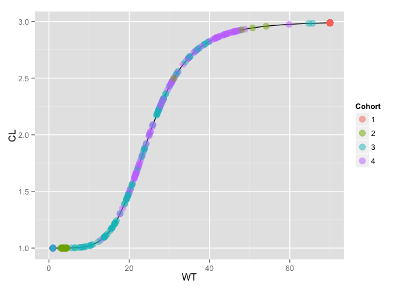

Weight optimization values per cohort relative to the true CL model. Results shown for all iterations.

```r
CL_mod <- function(params=list(BASE=1,EMAX=2,E50=25,HILL=5),IDV){
  with(params,{
    vals <- BASE+ (EMAX*IDV^HILL)/(E50^HILL + IDV^HILL)
    return(vals)
  })
}

df <- data.frame(WT=0:70)
df$CL=CL_mod(IDV=df$WT)

df.2 <- data.frame(all_designs$a)
df.2$CL=CL_mod(IDV=df.2$WT)
nrep <- length(grep("^iteration",names(results_all)))
ncohort <- size(df.2,1)/nrep
df.2$Cohort=as.factor(rep(1:ncohort,nrep))

p <- ggplot(data=df, aes(x=WT,y=CL))
p <- p+geom_line()
p <- p+geom_point(data=df.2,aes(color=Cohort),size=4,alpha=0.5)
p
```

Next we can examine the parameter estimates from this simulation experiment.

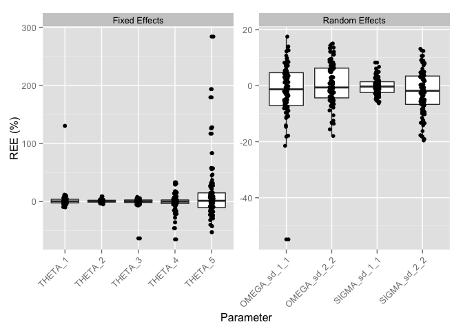

Parameter estimates for all 100 iterations.

```r
parameters_true_sd <- parameters_true
parameters_true_sd$d <- sqrt(parameters_true_sd$d)
parameters_true_sd$sigma <- sqrt(parameters_true_sd$sigma)

plot2 <- plot_parameter_estimates(results_all,unlist(parameters_true_sd))
plot2
```

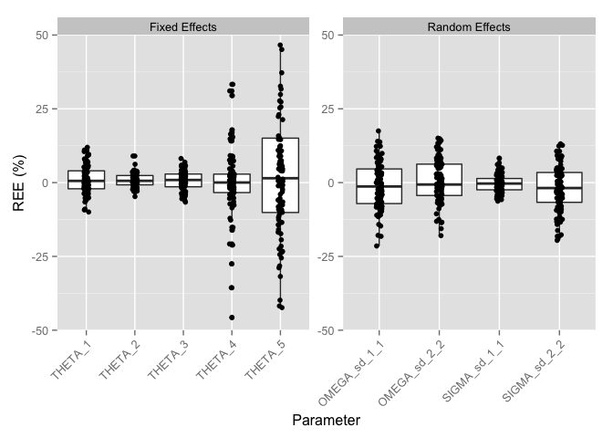

Parameter estimates for all 100 iterations.

```r
# Zoom in a bit
plot2a <- plot2 + coord_cartesian(xlim = NULL, ylim= c(-50,50))
plot2a
```

We see that there is no clear bias in parameter estimates and that they have relatively good precision.

We can simulate a population of individuals from the true parameter estimates and compare to the populations that are simulated from each of the parameter estimates in the 100 iterations of the MBAOD procedure. Here we simulate a population of individuals with a weight of 35 kg.

```r
design_1  <-  list(
  groupsize = 200,
  m=1,
  a   = 35,
  xt = c(0.5,1,2,3,6,12,24)
)

mbaod_vpc(design_1,
          model,
          parameters_true,
          results_all)



###########
# multiple groups here
###########

# design_2 = list(
#   groupsize = 200,
#   m=4,
#   a   = rbind(10, 35, 55, 70),
#   xt = c(0.5,1,2,3,6,12,24)
# )
#
# mbaod_vpc(design_2,
#           model,
#           parameters_true,
#           results_all,
#           separate.groups=T)
```

[figure not shown]

Visual predictive check of the MBAOD results given a design with a WT of 35 kg. Visualization is of a population of individuals using the true parameter values, showing the population prediction (PRED, black line) and the 2.5% and 97.5% of the individual predictions (IPRED, dotted lines). The red area is a 95% CI for the PRED predictions generated from the parameter estimates from the iterations in the MBAOD simulations. The blue areas are the 95% CI for the IPRED percentiles.

We can see a some deviation for both the 2.5% IPRED values. This deviation is potentially due to the low number of simulations (100) to capture just the 2.5 percentile. To what extent the deviation is important is, perhaps, situation dependent.

### 4.2.5 Simulation with PopED in R

We can compare the above results with the simulations done in PopED for R:

```r
results_all <-
  mbaod_simulate(cohorts=list(cohort_1_poped_sim,
                              cohort_2_poped_sim,
                              cohort_3_poped_sim),
                 ncohorts=4, # number of cohorts in one MBAOD
                 rep=100, #number of times to repeat the MBAOD simulation
                 name="Example_1_c",
                 description="4 cohorts, 1 group per cohort, simulate with PopED in R")
```

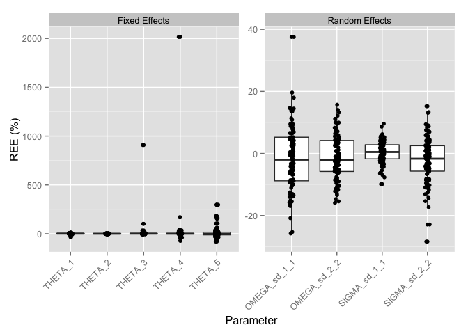

Parameter estimates for all 100 iterations.

```r
plot3 <- plot_parameter_estimates(results_all,unlist(parameters_true_sd))
plot3
```

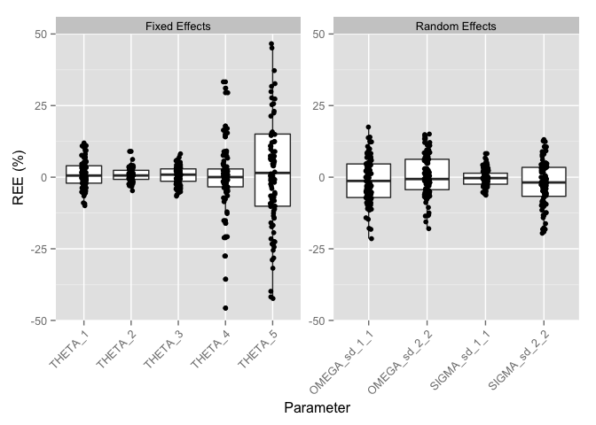

Parameter estimates for all 100 iterations.

```r
# Zoom in a bit
plot3a <- plot2 + coord_cartesian(xlim = NULL, ylim= c(-50,50))
plot3a
```

## 4.3 Design with 4 groups per cohort

We can compare the MBAOD setup described above with a setup that has 4 groups of patients per cohort.

```r
cohort_1=list(
  design = list(
    groupsize = 50,
    a = c(WT=70),
    xt = c(0.1,1,2,4,6,8,24)
  ),
  optimize=NULL,
  simulate=list(target="NONMEM", model="./NONMEM_files/sim.mod",
                data=list(dosing = list(list(AMT=1000,Time=0)),
                          manipulation = list(expression(AMT <- AMT*WT/70))
                )
  ),
  estimate=list(target="NONMEM", model="./NONMEM_files/est_red.mod")
)

cohort_2 = list(
  design = list(
    groupsize = 5,
    m=4,
    a   = t(rbind(WT=c(5,20,40,50))),
    xt = c(0.5,1,2,3,6,12,24)
  ),
  optimize=list(target="poped_R",
                model = list(
                  ff_file="PK.1.comp.maturation.ff",
                  fError_file="feps.add.prop",
                  fg_file="PK.1.comp.maturation.fg"
                ),
                design_space=list(maxa=70,
                                  mina=1,
                                  minxt=0,
                                  maxxt=24),
                parameters=list(
                  bpop=c(EMAX=2,EC50=5,HILL=5),
                  manipulation=list(expression(bpop[1] <- bpop[1]-bpop[3]))
                  ),
                settings.db=NULL,
                settings.opt=list(
                  opt_xt=T,
                  opt_a=T,
                  bUseRandomSearch= 1,
                  bUseStochasticGradient = 0,
                  bUseBFGSMinimizer = 0,
                  bUseLineSearch = 0,
                  compute_inv=F
                )
  ),
  simulate=cohort_1$simulate,
  estimate=list(target="NONMEM", model="./NONMEM_files/est_full.mod")
)

cohort_3 <- cohort_2
cohort_3$optimize$parameters <- NULL

results_all <- mbaod_simulate(cohorts=list(cohort_1,cohort_2,cohort_3),
                              ncohorts=4, # number of steps or cohorts in one AOD
                              rep=100, #number of times to repeat the MBAOD simulation
                              name="Example_1_d",
                              description="4 steps, 4 groups in steps 2-4")
```

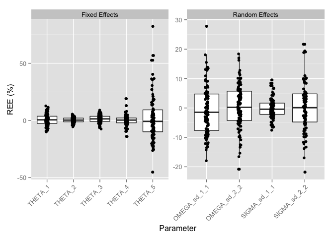

Parameter estimates for all 100 iterations.

```r
plot_parameter_estimates(results_all,unlist(parameters_true_sd))
```

We see fewer outliers, no other clear differences.